# FAFB_neuron_to_MIPmask

### Generate image stacks from FAFB neurons for MIP search

as described in Taisz and Galili et al., 2022

Data available via Virtual Fly Brain: https://fafb.catmaid.virtualflybrain.org/

MIP search described in Otsuna et al., 2018 https://www.biorxiv.org/content/10.1101/318006v1

MIP search online tool: https://neuronbridge.janelia.org/

```r
# run these lines if you don't have the natverse toolbox installed
# install.packages("natmanager")
# natmanager::install("natverse")

# load necessary packages and brain registration files
library("catmaid")
library("nat.jrcbrains")

# this will download some large files from the internet the first time
template_info=nat.jrcbrains::register_saalfeldlab_registrations()
required_templates=c("JRC2018F_FAFB", "JRC2018F_JRCFIB2018F", "JRC2018U_JRC2018F")
if(length(template_info)==0 || !all(required_templates %in% basename(names(template_info)))) {
  nat.jrcbrains::download_saalfeldlab_registrations()
}
```

```r
# set up connection to Virtual Fly Brain FAFB CATMAID instance and read neurons
vfbcatmaid = vfbcatmaid(dataset = "fafb")
# read neurons using the skeleton IDs of lvPNs (see Supplementary Table 2 / Connectomic identifiers for more IDs)
lvPN_nl = read.neurons.catmaid(c(57179, 57158, 57035))
```

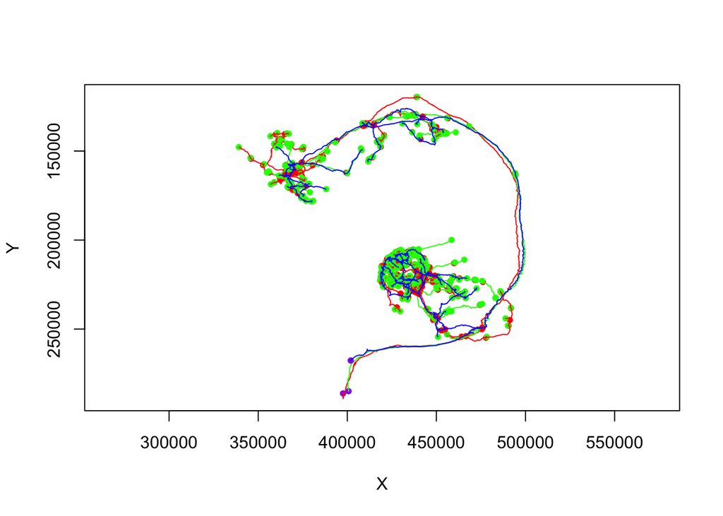

```r
# 3D plot of neurons
# nopen3d()
# plot3d(FAFB)
# plot3d(lvPN_nl)

# 2D plot of neurons
plot(lvPN_nl, main = NULL)
```

### Transform neurons to JRC2018U template from FAFB space and create a 3D image stack

```r
 # see Bates, Manton et al. 2020 and Bogovic et al. 2020; https://www.janelia.org/open-science/jrc-2018-brain-templates
lvPN_nl_x = xform_brain(lvPN_nl, sample = "FAFB14", reference = JRC2018U)

# the MIP images are in a downsampled version of this template (JRC2018U), define the downsampled dimensions
JRC2018Umip = templatebrain("JRC2018Umip", dims = c(1210,566,174), voxdims = c(0.519,0.519,1), units = "microns")
# create a 3D image of these neurons (this is a matrix the size of our image stack: 1210:566:174, with the appropriate voxel dimensions)
lvPN_im = as.im3d(xyzmatrix(lvPN_nl_x), JRC2018Umip)
# scale intensity values to fill 8bit range  (use the 95th percentile of intensity values)
perc95 = quantile(lvPN_im[lvPN_im > 0], c(0.95))
lvPN_im = floor(lvPN_im * 255/perc95)
lvPN_im[lvPN_im > 255] = 255
# hist(lvPN_im[lvPN_im > 0])
```

### Write out image stack

```r
# edit the filename to point to your target directory
# write the image stack out as an 8bit 3D .nrrd
filename = ".../your_path/lvPN_JRC2018Umip_raw.nrrd"
# write.im3d(lvPN_im, filename, dtype='byte')
```

### Generate a 2D color coded MIP image in ImageJ/Fiji

- Follow the instructions at https://github.com/JaneliaSciComp/ColorMIP_Mask_Search/tree/master/ColorDepthMIP_Generator
  - Download “Plugins_Color_MIP.zip” and decompress. Also download “Color_Depth_MIP_batch_0308_2021.ijm” (easiest is to clone the whole GitHub repository)
  - Copy “Plugins_Color_MIP” folder into Fiji/Plugins/ folder (please do not change the folder name, the name of folder is using as a link to the contents of .tiff/nrrd files).
  - Copy “Color_Depth_MIP_batch_0308_2021.ijm” into Fiji/Plugins/Macros/ folder.
  - Copy “PsychedelicRainBow2.lut” into Fiji/luts/ folder.
  - run Macro: Plugins/Macro/Color_Depth_MIP_batch_0308_2021.ijm
  - Select directory that contains 3D stacks to be color depth MIP
  - Select directory for saving MIPs (it has to be different than the one containing the 3D stacks)

### Upload the saved MIP file at https://neuronbridge.janelia.org/upload and select the option: `Aligned Color Depth 2D MIP`

- select the Target Image Library
  - Light Microscopy Libraries to find genetic driver lines that label your neuron
  - Electron Microscopy Libraries to find the matching neurons in the hemibrain dataset